# Topic 24

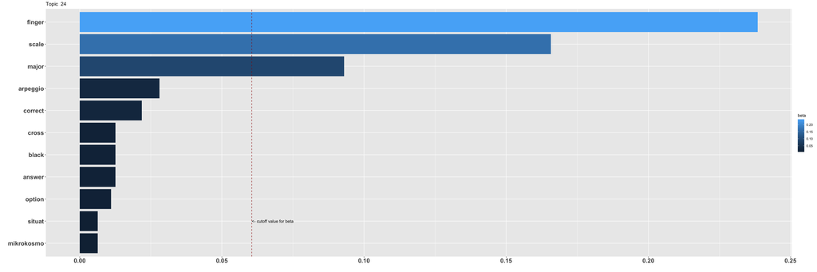

On interpreting beta: the term has a beta probability of being generated from the particular topic.

Values below are gamma : An estimated proportion of words from that document that are generated from that topic.

**Text Record Number: 488** gamma: 44 % likelihood of this document (based on its words) in this topic

**It’s amazing (but not surprising) that most pianists don’t have a good answer for this. It’s another one of those “because my teacher said so” things… and most of those teachers are doing it for the same reason without understanding why.

But there is a good answer.

Fingering on piano is basically about learning hundreds of small contingencies. It’s a lot of “if this, then that” situations. The thing is, without even realizing it, scale build in a TON of these almost through osmosis. Some people take away this idea that “I’m in this key so that means THIS finger goes on THIS pitch” but that’s not the take away you should be getting. It’s not your fault if you do… nobody ever explains it. Pair that with a lot of method books using concepts like “C position” which isn’t a thing and it start to make pianists feel like there is *A* single correct fingering for things… but there kind of isn’t.

So let’s look at some simple contingencies that scales accidentally build in.

- So you’re playing a C major scale and you get to B with your 4th finger and you’re only going up one octave… you only need one more finger… so you can put 5 on the top C.
- Or you’re playing C major and you hit B, but you’re going to play the next octave so there are more notes… so you’d cross over to allow more fingers to be available.
- Or a situation that you might *not* see practicing simple octave scales. Let’s say you have a scalar figure in C major… but it goes up to D and then back down. Instead of crossing after 3 you could cross after 4 to give yourself extra fingers…. and that’s something you might’ve realized from playing F major where (due to Bb being a black key) you *have* to cross after 4, but that gives you an extra finger available at the end.
- A bit more in the weeds is “which finger do I put on a black key?” Playing through scales like Bb, Eb, Ab, and Db, you may or may not start to notice that it’s a situation of “I have this many notes AFTER this black key so I need *this* many fingers and that decides what finger I use.”

Without realizing it, most people will instinctively use some of these fingerings that are used in scales and arpeggios (cadences are important too).

But for people who think a bit more black and white and think there “correct” fingering for every note and every passage, it sort of short circuits their brains a bit and they end up with questions like yours.

I’d generally encourage people to use the marked fingerings in pieces of music. Some absolutely don’t work for some hands and that’s fine, but just know if you’re deciding to not use a fingering because it’s not well suited to your hand versus it feeling awkward and unfamiliar. Almost EVERY new fingering feels awkward and unfamiliar at first, but the more options you have, the better.

Ultimately you’re building up a huge set of extra contingencies not covered by scale, arpeggios, and cadences. In the long-term you might be able to play any given passage equally comfortably with half a dozen fingering options and then you can just pick the one that is actually best for your hand *and* the music context.**

**Text Record Number: 1321** gamma: 44 % likelihood of this document (based on its words) in this topic

**So this is the way I practice piano in hopes of becoming a fluent player.

I made a sheet that lists all 12 major and all 12 minor triads on a sheet, and put them not that make up the triads next to the chord.

I.e.

C major- C-E-G C# major- c#- e#- g#

So I list them all like that, first all 12 major then below it all 12 minor triads.

SO how I am learning is that I am learning how to play all of those triads in the C octave. Moving up and down the octave on triad at a time.

After I master playing all 24 triads in the octave of C then I’m going to go to Learn how to play them in the octave F.

And then keep going all away around the circle of 5ths until I can fluently play all 24 major and minor triads on any octave.

The reason I do this is because someone told me once when you play in F major scale you are suppose to play in the octave of F. Not playing F majors scale in the octave of C.

So I guess it’s a two part question..

1. Is this a good learning strategy?
2. When you play in a certain scale, are you suppose to play using the scales key as the base of the octave? Like for instance again, if I’m paying F major scale, that means I should be using the 12 notes between two f keys? Is that correct?**

**Text Record Number: 1151** gamma: 44 % likelihood of this document (based on its words) in this topic

**Nothing really. But my girlfriend isn’t enjoying lessons anymore so I’m trying to help her find online resources to teach herself.

But for this example, I was testing out the fingerings for Bb natural minor.

It says to start the scale on Bb with finger number 2 on the right hand It says to end the scale on Bb with finder number 4 on the right hand

So going from finger 4 to finger 2 to carry on to the next octave feels incorrect and almost clunky/stretchy/painful.

Struck me as incorrect fingering if you were to proceed with the same fingering to the next octave.

When doing two octaves with Cmaj scale the finger flows effortlessly**

**Text Record Number: 102** gamma: 44 % likelihood of this document (based on its words) in this topic

**Yes this is common and has an evolutionary background. Since the index finger and thumb are the most used (and somehow most important) fingers, they evolved to be independently controllable.

“*The little finger actually moves easier than the middle and ring fingers. That’s because it also has independent muscles for some movements. However, it also relies on muscles shared with the other three fingers for some actions, thereby limiting your control.*” - indiatimes.com

If my interpretation is correct, your pinky “jumps” when you move either your ring or middle finger because they share some common muscles. I know it from playing guitar, you can train your hand and fingers to be more independent, but it takes a lot of exercise and time as such are unnatural movements for your fingers.

Just keep exercising and try to find some easy training to enforce the independence of your fingers. Don’t get frustrated, it is really a hard task.**

**Text Record Number: 1142** gamma: 44 % likelihood of this document (based on its words) in this topic

**The secret to scales is that you mostly play alternating groups of 3 & 4 fingers. Even on the scales that begin on the 2nd or 3rd finger you are really just beginning in the middle of a group of 3 or 4 fingers. There are exceptions. The more advanced you get the less scales become about hard coding finger patterns and instead you build an intuition. Here’s my video [unit](https://youtube.com/playlist?list=PL17VI8UqIaK8a22D3Hhi3ODS_RIuVNzL9) on two octave scales, [this one](https://youtu.be/ZREVi1RmZfA?t=329) specifically discusses the groups of 3 & 4 fingers concept.**

**Text Record Number: 390** gamma: 44 % likelihood of this document (based on its words) in this topic

**TL;DR To my knowledge, it’s generally up to you unless the music is written otherwise.

Unless you see finger numbers above or below the notes, usually it’s up to you. There are a few constants, like if you have a C major chord you would want to use your 1, 3, and 5 fingers. If you have an interval of a seventh, like from C to the next higher B, it wouldn’t be a good idea to use your 1 and 2 fingers! It’s much better to use your 1 and 5. If you see finger numbers, the composer figured out those are the best fingers to use in order to prepare you for what’s coming up next.**

**Text Record Number: 959** gamma: 44 % likelihood of this document (based on its words) in this topic

**These arpeggios are 16th notes where Quarter = 112, so pretty fast. I’m having trouble with fingering properly since they begin with notes that are not evenly spaced.

Bar 121 B flat major is simple. 521 321 321 down 231 231 etc.

Bar 122 is giving me a big problem.

Should I be doing 521 321 321 and cross from g to E flat on the way back down with thumb?

Or should I be doing 5321 421 and treat it as a normal e flat major arpeggio. I’m at a crossroads because the person who wrote the song does the former, but I feel like I should be using the “standard” fingering that people have drilled into my head.**